- Resource :- https://www.kaggle.com/datasets/nxtwaveda/data-analyst
- Tables Description

#### lead_basic_details

- lead_id: unique id of the lead
- age: age of the lead
- gender: gender of the lead
- current_city: city of residence of the lead
- current_education: current education details of the lead
- parent_occupation: occupation of the parent of the lead
- lead_gen_source: source from which the lead is generated

#### sales_managers_assigned_leads_details

- snr_sm_id: unique id of the senior sales manager
- jnr_sm_id: unique id of the junior sales manager
- assigned_date: date at which certain leads are assigned to junior sales manager
- cycle: cycle in which the lead is assigned
- lead_id: unique id of the lead

#### leads_interaction_details:

- jnr_sm_id: unique id of the junior sales manager
- lead_id: unique id of the lead
- lead_stage: stage of the lead when contacted by junior sales manager
- Stage can be “lead”, “awareness”, “consideration”, “conversion”
- call_done_date: date of call done to lead by junior sales manager
- call_status: status of the call made to the lead
- If lead answers the call then “successful”
- In all other cases “unsuccessful”
- call_reason: reason for calling the lead
- The reason depends on the stage lead is in.
- If lead is in “lead” stage, then reasons could be
- lead_introduction
- demo_scheduled
- demo_not_attended
- If lead is in “awareness” stage, then reasons could be
- after_demo_followup
- followup_for_consideration
- if lead is in “consideration” stage, then reasons could be
- interested_for_conversion
- followup_for_conversion
- if lead is in “conversion” stage, then reasons could be
- successful_conversion

#### leads_demo_watched_details

```python
import pandas as pd
import numpy as np
import matplotlib.pyplot as plt
%matplotlib inline
import seaborn as sns
```

```python
df1 = pd.read_csv("leads_basic_details.csv")
df2 = pd.read_csv("leads_interaction_details.csv")
df3 = pd.read_csv("leads_demo_watched_details.csv")
df4 = pd.read_csv("leads_reasons_for_no_interest.csv")
df5 = pd.read_csv("sales_managers_assigned_leads_details.csv")
```

```python
print("leads_basic_details :", df1.shape)
print("leads_interaction_details :", df2.shape)
print("leads_demo_watched_details :", df3.shape)
print("leads_reasons_for_no_interest :", df4.shape)
print("sales_managers_assigned_leads_details :", df5.shape)
```

```
leads_basic_details : (360, 7)
leads_interaction_details : (2192, 6)
leads_demo_watched_details : (194, 4)
leads_reasons_for_no_interest : (294, 4)
sales_managers_assigned_leads_details : (360, 5)
```

```python
print(df1.isnull().sum(), "\n")
print(df2.isnull().sum(), "\n")
print(df3.isnull().sum(), "\n")
print(df4.isnull().sum(), "\n")
print(df5.isnull().sum(), "\n")
```

```
lead_id              0
age                  0
gender               0
current_city         0
current_education    0
parent_occupation    0
lead_gen_source      0
dtype: int64

jnr_sm_id         0
lead_id           0
lead_stage        0
call_done_date    0
call_status       0
call_reason       0
dtype: int64

lead_id               0
demo_watched_date     0
language              0
watched_percentage    0
dtype: int64

lead_id                                     0
reasons_for_not_interested_in_demo        130
reasons_for_not_interested_to_consider    215
reasons_for_not_interested_to_convert     243
dtype: int64

snr_sm_id        0
jnr_sm_id        0
assigned_date    0
cycle            0
lead_id          0
dtype: int64
```

```python
dataframes = [df1, df2, df3, df4, df5]
for i in dataframes:
    i.info()
    print("\n")
```

```
<class 'pandas.core.frame.DataFrame'>
RangeIndex: 360 entries, 0 to 359
Data columns (total 7 columns):
 #   Column             Non-Null Count  Dtype
---  ------             --------------  -----
 0   lead_id            360 non-null    object
 1   age                360 non-null    int64
 2   gender             360 non-null    object
 3   current_city       360 non-null    object
 4   current_education  360 non-null    object
 5   parent_occupation  360 non-null    object
 6   lead_gen_source    360 non-null    object
dtypes: int64(1), object(6)
memory usage: 19.8+ KB


<class 'pandas.core.frame.DataFrame'>
RangeIndex: 2192 entries, 0 to 2191
Data columns (total 6 columns):
 #   Column          Non-Null Count  Dtype
---  ------          --------------  -----
 0   jnr_sm_id       2192 non-null   object
 1   lead_id         2192 non-null   object
 2   lead_stage      2192 non-null   object
 3   call_done_date  2192 non-null   object
 4   call_status     2192 non-null   object
 5   call_reason     2192 non-null   object
dtypes: object(6)
memory usage: 102.9+ KB


<class 'pandas.core.frame.DataFrame'>
RangeIndex: 194 entries, 0 to 193
Data columns (total 4 columns):
 #   Column              Non-Null Count  Dtype
---  ------              --------------  -----
 0   lead_id             194 non-null    object
 1   demo_watched_date   194 non-null    object
 2   language            194 non-null    object
 3   watched_percentage  194 non-null    int64
```

[output cut: 14 more lines]

```
memory usage: 9.3+ KB


<class 'pandas.core.frame.DataFrame'>
RangeIndex: 360 entries, 0 to 359
Data columns (total 5 columns):
 #   Column         Non-Null Count  Dtype
---  ------         --------------  -----
 0   snr_sm_id      360 non-null    object
 1   jnr_sm_id      360 non-null    object
 2   assigned_date  360 non-null    object
 3   cycle          360 non-null    int64
 4   lead_id        360 non-null    object
dtypes: int64(1), object(4)
memory usage: 14.2+ KB
```

```python
print("leads_basic_details :", df1.duplicated().sum())
print("leads_interaction_details :", df2.duplicated().sum())
print("leads_demo_watched_details :", df3.duplicated().sum())
print("leads_reasons_for_no_interest :", df4.duplicated().sum())
print("sales_managers_assigned_leads_details :", df5.duplicated().sum())
```

```
leads_basic_details : 0
leads_interaction_details : 438
leads_demo_watched_details : 0
leads_reasons_for_no_interest : 0
sales_managers_assigned_leads_details : 0
```

### Data Cleaning

#### 1. leads_basic_details

```python
df1.describe()
```

|  | age |
| --- | --- |
| count | 360.000000 |
| mean | 21.561111 |
| std | 11.555444 |
| min | 16.000000 |
| 25% | 18.000000 |
| 50% | 21.000000 |
| 75% | 24.000000 |
| max | 211.000000 |

```python
df1.age.unique()
```

```
array([ 16,  20,  21,  22,  25,  18,  24, 211, 116], dtype=int64)
```

```python
df1.query("age == (116, 211)")
```

|  | lead_id | age | gender | current_city | current_education | parent_occupation | lead_gen_source |
| --- | --- | --- | --- | --- | --- | --- | --- |
| 17 | USR1018 | 211 | MALE | Hyderabad | Degree | IT Employee | social_media |
| 300 | USR1301 | 116 | FEMALE | Hyderabad | Intermediate | Private Employee | social_media |

- May be by mistake 16 would have typed 116 and 21 typed 211. So I am replacing it in its original value.

```python
df1.age.replace(211, 21, inplace=True)
df1.age.replace(116, 16, inplace=True)

# df1.describe()
```

```python
print(df1.current_city.unique(), '\n')
print(df1.current_education.unique(), '\n')
print(df1.parent_occupation.unique(), '\n')
print(df1.lead_gen_source.unique(), '\n')
```

```
['Hyderabad' 'Bengaluru' 'Visakhapatnam' 'Mumbai' 'Chennai' 'Kochi']

['Intermediate' 'B.Tech' 'Degree' 'Looking for Job' '10th Completed'
 'Intermediate Completed']

['Private Employee' 'Business' 'Lawyer' 'IT Employee'
 'Government Employee' 'Doctor' 'Professor/Faculty']

['social_media' 'user_referrals' 'website' 'SEO' 'email_marketing']
```

```python
# I think, intermediate and intermediate completed both are same. So I replace it in one.

df1.loc[df1.current_education.isin(["Intermediate Completed", "Intermediate"])].head(2)
```

|  | lead_id | age | gender | current_city | current_education | parent_occupation | lead_gen_source |
| --- | --- | --- | --- | --- | --- | --- | --- |
| 0 | USR1001 | 16 | FEMALE | Hyderabad | Intermediate | Private Employee | social_media |
| 3 | USR1004 | 16 | MALE | Mumbai | Intermediate | IT Employee | user_referrals |

```python
df1.current_education.replace("Intermediate Completed", "Intermediate", inplace=True)
```

```python
df1.current_education.unique()
```

```
array(['Intermediate', 'B.Tech', 'Degree', 'Looking for Job',
       '10th Completed'], dtype=object)
```

```python
df1.to_csv("leads_basic_details_cln.csv")
```

#### 2. leads_interaction_details

```python
df2.columns
```

```
Index(['jnr_sm_id', 'lead_id', 'lead_stage', 'call_done_date', 'call_status',
       'call_reason'],
      dtype='object')
```

```python
df2.duplicated().sum()
```

```
438
```

```python
df2[df2.duplicated()].head(2)
```

|  | jnr_sm_id | lead_id | lead_stage | call_done_date | call_status | call_reason |
| --- | --- | --- | --- | --- | --- | --- |
| 8 | JNR1001MG | USR1002 | consideration | 1/7/2022 | successful | followup_for_conversion |
| 32 | JNR1001MG | USR1007 | consideration | 1/14/2022 | successful | followup_for_conversion |

```python
df2.drop_duplicates(keep='last', inplace=True, ignore_index=True)
```

```python
df2.duplicated().sum()
```

```
0
```

```python
print(df2.jnr_sm_id.unique(), '\n')
# print(df2.lead_id.unique(), '\n')
print(df2.lead_stage.unique(), '\n')
print(df2.call_done_date.unique(), '\n')
print(df2.call_status.unique(), '\n')
print(df2.call_reason.unique(), '\n')
```

```
['JNR1001MG' 'JNR1002MG' 'JNR1003MG' 'JNR1004MG' 'JNR1005MG' 'JNR1006MG'
 'JNR1007MG' 'JNR1008MG' 'JNR1009MG' 'JNR1010MG' 'JNR1011MG' 'JNR1012MG'
 'JNR1013MG' 'JNR1014MG' 'JNR1015MG' 'JNR1016MG']

['lead' 'awareness' 'consideration' 'conversion']

['1/2/2022' '1/3/2022' '1/4/2022' '1/5/2022' '1/6/2022' '1/7/2022'
 '1/8/2022' '1/9/2022' '1/1/2022' '1/10/2022' '1/12/2022' '1/13/2022'
 '1/11/2022' '1/14/2022' '1/15/2022' '1/16/2022' '1/20/2022' '1/21/2022'
 '1/22/2022' '1/17/2022' '1/18/2022' '1/19/2022' '2/19/2022' '2/21/2022'
 '2/20/2022' '2/22/2022' '2/23/2022' '2/24/2022' '2/25/2022' '1/27/2022'
 '1/28/2022' '1/29/2022' '2/26/2022' '2/27/2022' '2/28/2022' '1/24/2022'
 '1/26/2022' '1/25/2022' '1/23/2022' '3/1/2022']

['successful' 'unsuccessful']

['lead_introduction' 'demo_schedule' 'post_demo_followup'
 'followup_for_consideration' 'interested_for_conversion'
 'followup_for_conversion' 'successful_conversion' 'demo_not_attended']
```

```python
df2.to_csv("leads_interaction_details_cln.csv")
```

#### 3. leads_demo_watched_details

```python
df3.head()
```

|  | lead_id | demo_watched_date | language | watched_percentage |
| --- | --- | --- | --- | --- |
| 0 | USR1002 | 1/4/2022 | Telugu | 42 |
| 1 | USR1003 | 1/7/2022 | Telugu | 81 |
| 2 | USR1004 | 1/2/2022 | Telugu | 35 |
| 3 | USR1005 | 1/3/2022 | Hindi | 38 |
| 4 | USR1006 | 1/12/2022 | Hindi | 54 |

```python
print(df3.lead_id.unique(), '\n')
print(df3.demo_watched_date.unique(), '\n')
print(df3.language.unique(), '\n')
print(df3.watched_percentage.unique(), '\n')
```

```
['USR1002' 'USR1003' 'USR1004' 'USR1005' 'USR1006' 'USR1007' 'USR1008'
 'USR1009' 'USR1010' 'USR1011' 'USR1012' 'USR1013' 'USR1014' 'USR1015'
 'USR1016' 'USR1017' 'USR1018' 'USR1019' 'USR1020' 'USR1021' 'USR1022'
 'USR1023' 'USR1024' 'USR1025' 'USR1026' 'USR1027' 'USR1028' 'USR1029'
 'USR1030' 'USR1031' 'USR1032' 'USR1033' 'USR1034' 'USR1035' 'USR1036'
 'USR1037' 'USR1038' 'USR1039' 'USR1040' 'USR1041' 'USR1042' 'USR1043'
 'USR1044' 'USR1045' 'USR1046' 'USR1047' 'USR1050' 'USR1051' 'USR1052'
 'USR1053' 'USR1055' 'USR1057' 'USR1058' 'USR1062' 'USR1063' 'USR1065'
 'USR1067' 'USR1070' 'USR1071' 'USR1072' 'USR1073' 'USR1075' 'USR1077'
 'USR1078' 'USR1082' 'USR1083' 'USR1087' 'USR1090' 'USR1091' 'USR1092'
 'USR1093' 'USR1095' 'USR1097' 'USR1098' 'USR1102' 'USR1103' 'USR1105'
 'USR1107' 'USR1110' 'USR1111' 'USR1112' 'USR1113' 'USR1115' 'USR1117'
 'USR1118' 'USR1122' 'USR1123' 'USR1127' 'USR1130' 'USR1131' 'USR1132'
 'USR1133' 'USR1135' 'USR1137' 'USR1138' 'USR1142' 'USR1143' 'USR1145'
 'USR1147' 'USR1150' 'USR1151' 'USR1152' 'USR1153' 'USR1155' 'USR1157'
 'USR1158' 'USR1162' 'USR1163' 'USR1167' 'USR1170' 'USR1171' 'USR1172'
 'USR1173' 'USR1175' 'USR1177' 'USR1178' 'USR1182' 'USR1183' 'USR1185'
 'USR1187' 'USR1190' 'USR1191' 'USR1192' 'USR1193' 'USR1195' 'USR1197'
 'USR1198' 'USR1202' 'USR1203' 'USR1207' 'USR1210' 'USR1211' 'USR1212'
 'USR1213' 'USR1215' 'USR1217' 'USR1218' 'USR1222' 'USR1223' 'USR1225'
 'USR1227' 'USR1230' 'USR1231' 'USR1232' 'USR1233' 'USR1235' 'USR1237'
 'USR1238' 'USR1242' 'USR1243' 'USR1247' 'USR1250' 'USR1251' 'USR1252'
 'USR1253' 'USR1255' 'USR1257' 'USR1258' 'USR1262' 'USR1263' 'USR1265'
 'USR1267' 'USR1270' 'USR1271' 'USR1272' 'USR1273' 'USR1275' 'USR1277'
 'USR1278' 'USR1282' 'USR1283' 'USR1287' 'USR1290' 'USR1291' 'USR1292'
 'USR1293' 'USR1295' 'USR1297' 'USR1298' 'USR1302' 'USR1303' 'USR1305'
 'USR1307' 'USR1310' 'USR1311' 'USR1312' 'USR1313' 'USR1314' 'USR1315'
 'USR1317' 'USR1318' 'USR1319' 'USR1343' 'USR1348']

['1/4/2022' '1/7/2022' '1/2/2022' '1/3/2022' '1/12/2022' '1/11/2022'
 '1/8/2022' '1/10/2022' '1/17/2022' '1/16/2022' '1/18/2022' '2/21/2022'
 '2/19/2022' '2/20/2022' '1/1/2022' '1/6/2022' '1/9/2022' '1/21/2022'
 '1/19/2022' '2/22/2022' '2/25/2022' '2/23/2022' '1/5/2022' '1/20/2022'
 '1/26/2022' '1/13/2022' '1/22/2022' '2/26/2022' '1/14/2022' '2/28/2022'
 '1/25/2022' '2/27/2022']

['Telugu' 'Hindi' 'English']

[ 42  81  35  38  54  52  41  50  48  44  46  51  47  40  36 100   5  53
   8  10  11  14  17  20  23  55  73  26  29  32  56  59  62  60  65  70
  74  75  68  85  71  86  87  88  89   2  90  91  92  77  80  63  83  25
   3   4  30  45  64 510  37  66  67  49  57  69  61  95  15  12  13  72
  19 233  27  21  16  76  18  79  78  22  24  28  82  84]
```

#### 4. leads_reasons_for_no_interest

```python
df4
```

|  | lead_id | reasons_for_not_interested_in_demo | reasons_for_not_interested_to_consider | reasons_for_not_interested_to_convert |
| --- | --- | --- | --- | --- |
| 0 | USR1001 | No time for student | NaN | NaN |
| 1 | USR1003 | NaN | No time for student | NaN |
| 2 | USR1004 | NaN | Wants offline classes | NaN |
| 3 | USR1005 | NaN | Can't afford | NaN |
| 4 | USR1006 | NaN | Student not interested in domain | NaN |
| ... | ... | ... | ... | ... |
| 289 | USR1356 | Cannot afford | NaN | NaN |
| 290 | USR1357 | Cannot afford | NaN | NaN |
| 291 | USR1358 | Wants offline classes | NaN | NaN |
| 292 | USR1359 | Will join in final year | NaN | NaN |
| 293 | USR1360 | Will join in final year | NaN | NaN |

294 rows × 4 columns

```python
print(df4.reasons_for_not_interested_in_demo.unique(), '\n')
print(df4.reasons_for_not_interested_to_consider.unique(), '\n')
print(df4.reasons_for_not_interested_to_convert.unique(), '\n')
```

```
['No time for student' nan 'Student not interested in domain'
 'Wants offline classes' "Can't afford" 'Cannot afford'
 'Will join in final year']

[nan 'No time for student' 'Wants offline classes' "Can't afford"
 'Student not interested in domain' 'Will join in final year']

[nan "Can't afford" 'Will join in final year' 'No time for student'
 'Student not interested in domain' 'Wants offline classes']
```

```python
df4.shape
```

```
(294, 4)
```

```python
df4.isnull().sum()
```

```
lead_id                                     0
reasons_for_not_interested_in_demo        130
reasons_for_not_interested_to_consider    215
reasons_for_not_interested_to_convert     243
dtype: int64
```

#### 5. sales_managers_assigned_leads_details

```python
df5.head(5)
```

|  | snr_sm_id | jnr_sm_id | assigned_date | cycle | lead_id |
| --- | --- | --- | --- | --- | --- |
| 0 | SNR501MG | JNR1001MG | 1/1/2022 | 1 | USR1001 |
| 1 | SNR501MG | JNR1001MG | 1/1/2022 | 1 | USR1002 |
| 2 | SNR501MG | JNR1001MG | 1/1/2022 | 1 | USR1003 |
| 3 | SNR501MG | JNR1001MG | 1/1/2022 | 1 | USR1004 |
| 4 | SNR501MG | JNR1001MG | 1/1/2022 | 1 | USR1005 |

```python
print(df5.snr_sm_id.unique(), '\n')
print(df5.jnr_sm_id.unique(), '\n')
print(df5.assigned_date.unique(), '\n')
print(df5.cycle.unique(), '\n')
# print(df5.lead_id.unique(), '\n')
```

```
['SNR501MG' 'SNR502MG' 'SNR503MG' 'SNR504MG']

['JNR1001MG' 'JNR1002MG' 'JNR1003MG' 'JNR1004MG' 'JNR1005MG' 'JNR1006MG'
 'JNR1007MG' 'JNR1008MG' 'JNR1009MG' 'JNR1010MG' 'JNR1011MG' 'JNR1012MG'
 'JNR1013MG' 'JNR1014MG' 'JNR1015MG' 'JNR1016MG']

['1/1/2022' '1/8/2022' '1/15/2022' '2/19/2022']

[1 2 3 4]
```

## Data Visualization

#### I have created a dashboard on Power BI, where I have solve all these question.

#### Based on some questions, We will found out solutions with visuals.

- What is the age distribution?
- Count of age by gender!
- Maximum and minimum educational qualification of the leads!
- from which city/State the leads belong over qualification?
- source from which the lead is generated!
- What is occupation of the parent of the lead?
- Total leads including Male and Female counts!
- What is the average watched percentage?
- What is the ratio of languges of the leads?
- What is the average count percentage over languages of the leads?
- Which language is the most common for the lead over city/State?
- What is the call status of the lead?

[output not shown]

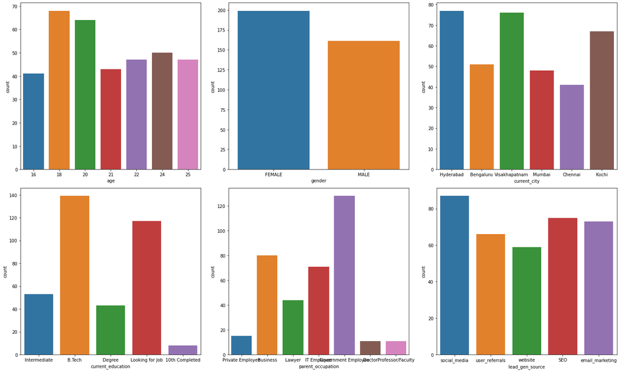

```python
plt.figure(figsize=(20,12))

plt.subplot(2,3,1)
sns.countplot(df.age)

plt.subplot(2,3,2)
sns.countplot(df.gender)

plt.subplot(2,3,3)
sns.countplot(df.current_city)

plt.subplot(2,3,4)
sns.countplot(df.current_education)

plt.subplot(2,3,5)
sns.countplot(df.parent_occupation)

plt.subplot(2,3,6)
sns.countplot(df.lead_gen_source)

plt.tight_layout()
plt.show()
```

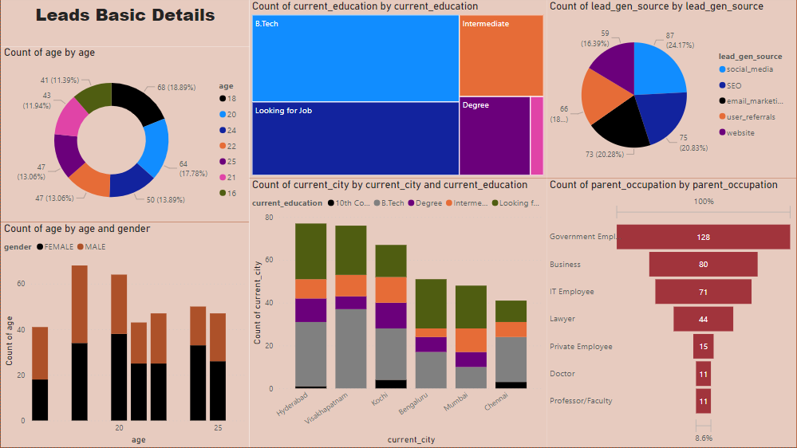

```python
from IPython.display import Image
Image(filename = "page1.png", width=1000)
```

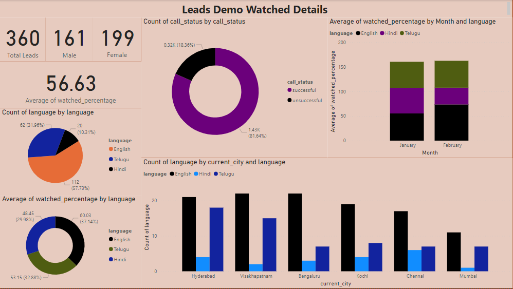

```python
Image(filename = "page2.png", width=1000)
```

#### Conclusion

- Maximum and minimum lead's age is 18(68, 18.89%) and 16(41, 11.39%) respectibly.
- Maximum educational qualification of the leads is B.Tech(139) and minimum 10th(8).
- Maximum leads are from Hydrabad(77) and minimum are from Chennai(41).
- Social Media(24.17), SEO(20.83) and E-mail Marketing(20.28) helped most to reach out to the leads.
- Maximum lead's parents have Government Job(128) and minimum are Professor/Faculty(11).
- Total no of leads 360 in which 161 are male and 199 are female.
- Average percentage of watched is 56.63%.
- Leads prefers language English(57.73%), Telugu(31.96%) and Hindi(10.31%)
- Average of watched percentage is English(37.14%), Telugu(32.88%) and Hindi(29.98%).
- English language leads over all Cities/States

#### Call status is :

- Successful = 81.64%
- Unsuccessful = 18.36%
- Which is showing very good percentage to hiring along with these strategies.